# DataPy Pipeline

This notebook will showcase a basic data science pipeline. It'll use artificially generated data on the motion of objects in a freefall. The data has been generated using the general freefall motion equation. ( Please check the data generation notebook for more information)

The goal would be to apply a classic data science pipeline to such data, and compare the perfomance of different models and methodologies. The notebook will be commented at each stage.

```python
import numpy as np
import pandas as pd
import seaborn as sns


import timeit
from sklearn.svm import SVR
from sklearn.model_selection import train_test_split
from sklearn.metrics import classification_report
from sklearn.metrics import r2_score
from sklearn.linear_model import LinearRegression
from sklearn.linear_model import ElasticNet
from sklearn.ensemble import RandomForestRegressor
from sklearn.svm import LinearSVR
from sklearn.svm import SVR
from sklearn.neighbors import KNeighborsRegressor

from sklearn.pipeline import Pipeline
from sklearn.preprocessing import StandardScaler
from sklearn.feature_extraction.text import CountVectorizer, TfidfTransformer
from sklearn.model_selection import train_test_split
from sklearn.svm import LinearSVC
from sklearn.pipeline import make_pipeline
from sklearn.naive_bayes import MultinomialNB
from sklearn.preprocessing import Binarizer
import warnings
warnings.filterwarnings("ignore")
```

```python
#Loading Data
df0 = pd.read_pickle('/home/clemente/PycharmProjects/P2/utl/kvelocity.pkl')
```

## Descriptive Statistic - Artificial Dataset

```python
df0.info()
df0.describe()
```

```
<class 'pandas.core.frame.DataFrame'>
RangeIndex: 3000000 entries, 0 to 2999999
Data columns (total 4 columns):
distance        int64
acceleration    int64
time            int64
velocity        float64
dtypes: float64(1), int64(3)
memory usage: 91.6 MB
```

|  | distance | acceleration | time | velocity |
| --- | --- | --- | --- | --- |
| count | 3.000000e+06 | 3.000000e+06 | 3.000000e+06 | 3.000000e+06 |
| mean | 7.932582e+01 | 7.930143e+01 | 5.100686e+01 | 2.019261e+03 |
| std | 6.029569e+01 | 6.030134e+01 | 2.915089e+01 | 2.118640e+03 |
| min | 0.000000e+00 | 0.000000e+00 | 1.000000e+00 | -4.180000e+02 |
| 25% | 3.100000e+01 | 3.100000e+01 | 2.600000e+01 | 4.562046e+02 |
| 50% | 6.700000e+01 | 6.700000e+01 | 5.100000e+01 | 1.317345e+03 |
| 75% | 1.150000e+02 | 1.140000e+02 | 7.600000e+01 | 2.899930e+03 |
| max | 4.900000e+02 | 5.090000e+02 | 1.010000e+02 | 2.373355e+04 |

```python
df0.head(4)
```

|  | distance | acceleration | time | velocity |
| --- | --- | --- | --- | --- |
| 0 | 13 | 37 | 63 | 1165.293651 |
| 1 | 49 | 16 | 64 | 511.234375 |
| 2 | 159 | 2 | 1 | -158.000000 |
| 3 | 23 | 143 | 54 | 3860.574074 |

The dataset is a cross-sectional type. The random variables are numerical ordinal. Negative velocity variables shouldn't be present in the experiment. Let's remove them.

```python
#Creating a new dataset subselecting only the rows where velocity is positive:

df = df0[df0['velocity'] > 0]

print(len(df0) - len(df), "observations lost")
```

```
64105 observations lost
```

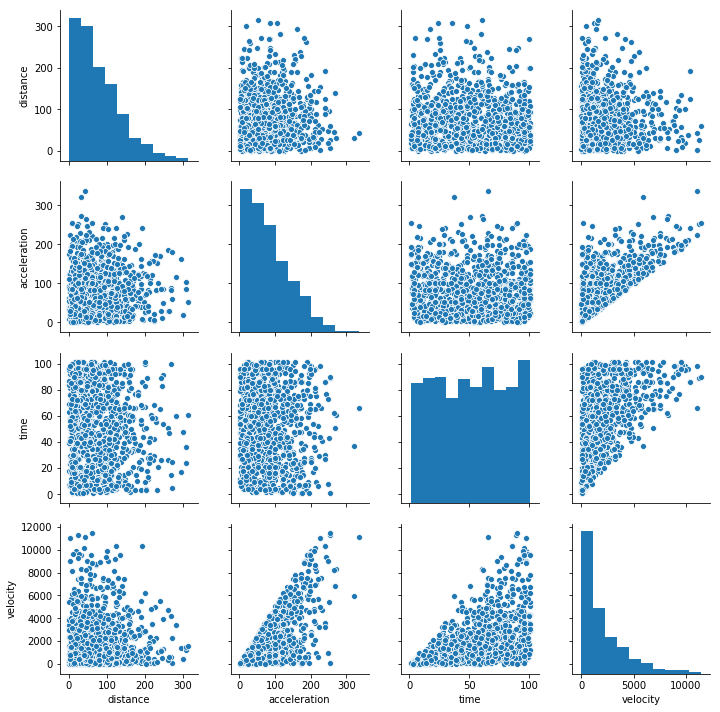

```python
#Plotting scatterplots to check for random variable correlations (WARNING: Very Long Computation)
sns.pairplot(df[:1000])

#NB: pick 10000 random observations

#NB: 3m points are too much for seaborn to print reliably. Build a library to
#to substitute the pairplot with linear correlation coefficient and poly-reg r-squared
```

## Descriptive Statistics results:

Dependent variable: velocity.

As shown in the last row: velocity has somewhat a linear relationship with time and acceleration, and an inverse quadratic one with distance.

The independent variables have no particular relationship between them.

### Data Preprocessing

Scaling and normalization will be applied to ease any distance-based algorithm, including gradient descent. Tree-Based models, LDA and Naive Bayes are not affected by it.

However let's see how the data changes as we apply different transformations.

```python
#Let's build a function for all of them and test them on a sample

df1 = df[:10000]
```

```python
#Standard Scaling (Standardization)

def standard_scaling(X):
    """
    Given an X random variable as a pandas dataframe
    applies the transformation formula, X = (x - X_mean)/X_std
    :param data: X
    :return: Standardized X_std on success
    """

    #Manually checking and enforcing datatype
    if type(X) == type(pd.DataFrame()):
        print("X type is pandas DataFrame")
        pass
    else:
        print("X type is not Pandas DataFrame")
        return -1
    return X.transform(lambda x: ((x-x.mean())/(x.std())))
```

```
X type is pandas DataFrame
```

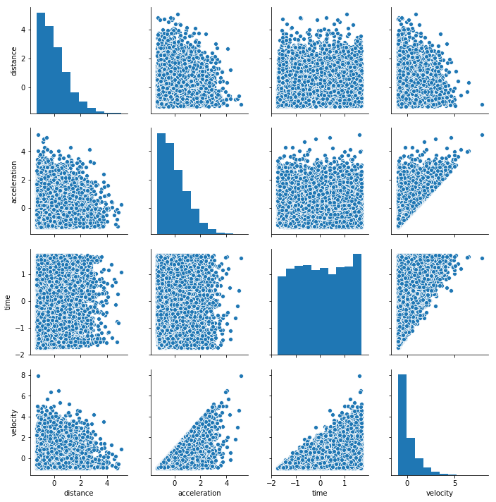

```python
df2 = standard_scaling(df1)
sns.pairplot(data=df2)
```

```python
#Scaling
# transformation formula, X = (x - X_min)/(X_max-X_min)

def scaling(X):
    """
    Given an X random variable as a pandas dataframe
    applies the transformation formula, X = (x - X_min)/(X_max - X_min)
    :param data: X
    :return: Standardized X_sc on success
    """

    #Manually checking and enforcing datatype
    if type(X) == type(pd.DataFrame()):
        print("X type is pandas DataFrame")
        pass
    else:
        print("X type is not Pandas DataFrame")
        return -1
    return X.transform(lambda x: ((x-x.min())/(x.max()-x.min())))
```

```
X type is pandas DataFrame
```

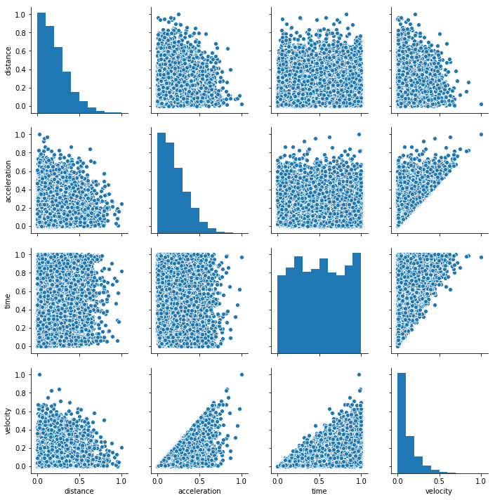

```python
df2 = scaling(df1)
sns.pairplot(data=df2)
```

```python
#Normalization

def normalization(X):
    """
    Given an X random variable as a pandas dataframe
    applies the transformation formula, X = (x - X_mean)/(X_max - X_min)
    :param data: X
    :return: Standardized X_norm on success
    """

    #Manually checking and enforcing datatype
    if type(X) == type(pd.DataFrame()):
        print("X type is pandas DataFrame")
        pass
    else:
        print("X type is not Pandas DataFrame")
        return -1
    return X.transform(lambda x: ((x-x.mean())/(x.max()-x.min())))
```

```
X type is pandas DataFrame
```

[figure not shown]

```python
df2 = scaling(df1)
sns.pairplot(data=df2)
```

### Data Preprocessing Results

The random variables distribution did not change much. But the scaling effect centered the observations around a median for each random variable.

```python
#Modular Slice


y = (df['velocity'])
X = df.drop(columns=['velocity'])

print(len(X))
print(len(y))
```

```
2935895
2935895
```

```python
X = X.iloc[:1000,:]
y = y.iloc[:1000]
```

## Readying Pipelines

We will use standard scaler with three different model: LinearRegression, KNN and a Random Forest Regression. The latter could work properly even without the standard scaler

```python
#LinReg Pipeline
pipe_lin = Pipeline([
    ('Scaling', StandardScaler()),
    ('LinReg', LinearRegression()),
])
#KNN Pipeline
pipe_KNN = Pipeline([
    ('Scale', StandardScaler()),
    ('LSVR', KNeighborsRegressor(n_neighbors=2)),
])
#RF Pipeline
pipe_RFreg = Pipeline([
    ('Scaling', StandardScaler()),
    ('RFreg', RandomForestRegressor()),
])
```

## Model Comparison

Since the data is artificially generated and its composition is random, a simple train-test split will be applied. There would be no improvement in using a K-fold crossvalidation. Although we will repeat the pipelines for each model and and at every run we will increase the sample size to check which model is more consistent.

```python
#Defining functions for a basic train-test split
def run_pipe(pipe_name, X, y):

    X_train, X_test, y_train, y_test = train_test_split(X, y)
    pipe_name.fit(X_train, y_train)

    #pipe.predict(X_test)

    return pipe_name.score(X ,y)

def run_svm(X,y):
    sc =StandardScaler()
    X = sc.fit_transform(X)

    regr = SVR()
    regr.fit(X, y)
    return regr.score(X,y)
```

```python
start = timeit.default_timer()

l_lin = []
l_KNN = []
l_RFreg = []
l_X = []
counter = 1

for n in range(3,len(X),10):

    X1 = X[:n]
    y1 = y[:n]

    l_lin.append(run_pipe(pipe_lin, X1, y1))
    l_KNN.append(run_pipe( pipe_KNN, X1, y1))
    l_RFreg.append(run_pipe(pipe_RFreg, X1, y1))
    l_X.append(len(X1))
    print(counter, len(X1))
    counter += 1


stop = timeit.default_timer()

print('Time: ', stop - start)
```

```
1 3
2 13
3 23
4 33
5 43
6 53
7 63
8 73
9 83
10 93
11 103
12 113
13 123
14 133
15 143
```

[output cut: 86 more lines]

```python
#Storing the results
d = {
    'OLS': l_lin,
    'KNN reg': l_KNN,
    'RF reg': l_RFreg,
    'n': l_X
    }

df_r1 = pd.DataFrame(d)
#df_r2 = pd.DataFrame(d)
df_r1
```

|  | OLS | KNN reg | RF reg | n |
| --- | --- | --- | --- | --- |
| 0 | 0.776084 | -0.211883 | 0.694057 | 3 |
| 1 | 0.926603 | 0.763545 | 0.764567 | 13 |
| 2 | 0.905134 | 0.830491 | 0.921208 | 23 |
| 3 | 0.875687 | 0.935223 | 0.805949 | 33 |
| 4 | 0.840079 | 0.874187 | 0.959822 | 43 |
| 5 | 0.837668 | 0.925760 | 0.955470 | 53 |
| 6 | 0.841305 | 0.888838 | 0.900259 | 63 |
| 7 | 0.846176 | 0.949071 | 0.943729 | 73 |
| 8 | 0.855668 | 0.943564 | 0.964151 | 83 |
| 9 | 0.847319 | 0.951232 | 0.956053 | 93 |
| 10 | 0.849974 | 0.927208 | 0.944010 | 103 |
| 11 | 0.867868 | 0.957332 | 0.975989 | 113 |
| 12 | 0.874665 | 0.969544 | 0.984290 | 123 |
| 13 | 0.862000 | 0.958020 | 0.982441 | 133 |
| 14 | 0.875590 | 0.958573 | 0.969537 | 143 |
| 15 | 0.868419 | 0.964323 | 0.989754 | 153 |
| 16 | 0.870457 | 0.967671 | 0.984667 | 163 |
| 17 | 0.867428 | 0.957524 | 0.984852 | 173 |
| 18 | 0.862641 | 0.962786 | 0.981552 | 183 |
| 19 | 0.863549 | 0.958636 | 0.980959 | 193 |
| 20 | 0.860419 | 0.969124 | 0.973171 | 203 |
| 21 | 0.861364 | 0.976963 | 0.988021 | 213 |
| 22 | 0.859515 | 0.964866 | 0.989910 | 223 |
| 23 | 0.851570 | 0.967116 | 0.982063 | 233 |
| 24 | 0.850501 | 0.978434 | 0.993363 | 243 |
| 25 | 0.851403 | 0.974977 | 0.992239 | 253 |
| 26 | 0.851317 | 0.976653 | 0.995057 | 263 |
| 27 | 0.850002 | 0.977549 | 0.994039 | 273 |
| 28 | 0.848639 | 0.969442 | 0.993951 | 283 |
| 29 | 0.846548 | 0.972995 | 0.991448 | 293 |
| ... | ... | ... | ... | ... |
| 70 | 0.842350 | 0.986122 | 0.995435 | 703 |
| 71 | 0.841332 | 0.987615 | 0.996146 | 713 |
| 72 | 0.839907 | 0.985713 | 0.995436 | 723 |
| 73 | 0.839361 | 0.984148 | 0.993976 | 733 |
| 74 | 0.839452 | 0.985835 | 0.994421 | 743 |
| 75 | 0.840088 | 0.981382 | 0.992777 | 753 |
| 76 | 0.838935 | 0.981903 | 0.996522 | 763 |
| 77 | 0.839818 | 0.982543 | 0.995282 | 773 |
| 78 | 0.839229 | 0.981332 | 0.993581 | 783 |
| 79 | 0.840485 | 0.982257 | 0.994967 | 793 |
| 80 | 0.841620 | 0.981627 | 0.995294 | 803 |
| 81 | 0.842845 | 0.983132 | 0.996663 | 813 |
| 82 | 0.841845 | 0.984731 | 0.997551 | 823 |
| 83 | 0.842724 | 0.984557 | 0.996007 | 833 |
| 84 | 0.841902 | 0.979440 | 0.996806 | 843 |
| 85 | 0.842081 | 0.982885 | 0.997586 | 853 |
| 86 | 0.840476 | 0.983746 | 0.995563 | 863 |
| 87 | 0.840172 | 0.985737 | 0.996129 | 873 |
| 88 | 0.836049 | 0.983381 | 0.993655 | 883 |
| 89 | 0.835341 | 0.982674 | 0.994628 | 893 |
| 90 | 0.832985 | 0.984685 | 0.996463 | 903 |
| 91 | 0.833506 | 0.985695 | 0.991916 | 913 |
| 92 | 0.832891 | 0.985071 | 0.994085 | 923 |
| 93 | 0.833187 | 0.982895 | 0.996591 | 933 |
| 94 | 0.833100 | 0.983688 | 0.995334 | 943 |
| 95 | 0.832656 | 0.986334 | 0.997239 | 953 |
| 96 | 0.833109 | 0.981050 | 0.995948 | 963 |
| 97 | 0.834238 | 0.985116 | 0.997057 | 973 |
| 98 | 0.836744 | 0.984344 | 0.994931 | 983 |
| 99 | 0.837117 | 0.985656 | 0.997733 | 993 |

100 rows × 4 columns

```python
df_m1 = pd.melt(df_r1, value_vars=['OLS','KNN reg', 'RF reg'], id_vars=['n'])
df_m1 = df_m1.rename(columns={'variable':'model','values':'accuracy'})
```

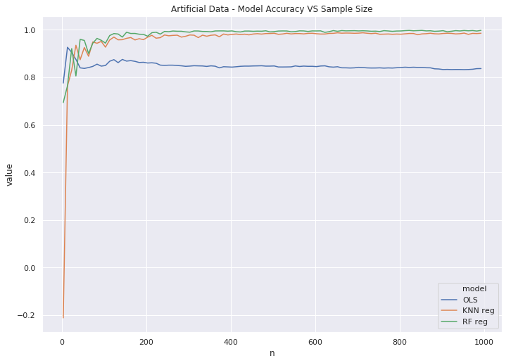

```python
sns.set(rc={'figure.figsize':(11.7,8.27)})
sns.lineplot(data=df_m1,y='value',x='n',hue='model').set_title('Artificial Data - Model Accuracy VS Sample Size')
```

### Comparison Results

The value axis carries the accuracy score for each model as the sample size increases. It shows how a simple OLS is performing better than more complex models for very low sample sizes. However as the sample increases both the KNN and the RF regression outperform the OLS consistently. Also for this particular dataset a plateau in perfomance is achieved with a sample size of roughly 200 observations.